# 14 Limits

Consider the problem of finding the area under the graph of $f(x)=x^2$ between $[0,1]$. There isn’t a ready-made formula for the area of this shape, as there is for a triangle or a square. However, [Archimedes](http://en.wikipedia.org/wiki/The_Quadrature_of_the_Parabola) found a method to compute areas enclosed by a parabola and line segments that cross the parabola.

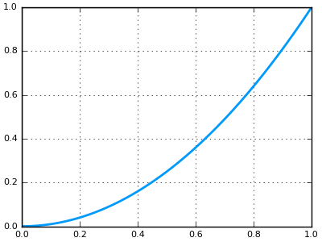

[Fermat](http://en.wikipedia.org/wiki/Adequality) in the 1600s essentially took a limit to find the slope of a tangent line to a polynomial curve. Newton in the late 1600s, exploited the idea in his development of calculus (as did Leibniz). Yet it wasn’t until the 1800s that [Bolzano](http://en.wikipedia.org/wiki/Limit_of_a_function#History), Cauchy and Weierstrass put the idea on a firm footing.

To make things more precise, we begin by discussing the limit of a function as $x$ approaches $c$.

Informally, if a limit exists it is the value that $f(x)$ gets close to as $x$ gets close to, but not equal to, $c$.

The modern formulation is due to Weirstrass:

> The limit of $f(x)$ as $x$ approaches $c$ is $L$ if for every real $\epsilon > 0$, there exists a real $\delta > 0$ such that for all real $x$, $0 < \lvert x − c \rvert < \delta$ implies $\lvert f(x) − L \rvert < \epsilon$. The notation used is $\lim_{x \rightarrow c}f(x) = L$.

Cauchy begins his [treatise](http://gallica.bnf.fr/ark:/12148/bpt6k90196z/f25.image) on calculus considering two examples, the limit as $x$ goes to $0$ of
$$~ \frac{\sin(x)}{x} \quad\text{and}\quad (1 + x)^{1/x}. ~$$

These take the indeterminate forms $0/0$ and $1^\infty$, which are found by just putting $0$ in for $x$. An expression does not need to be defined at $c$, as these two aren’t, to discuss the limit. Cauchy illustrates two methods to approach the questions above. The first is to pull out an inequality:
$$~
\frac{\sin(x)}{\sin(x)} > \frac{\sin(x)}{x} > \frac{\sin(x)}{\tan(x)}.
~$$

This bounds the expression $\sin(x)/x$ between $1$ and $\cos(x)$ and as $x$ gets close to $0$, the value of $\cos(x)$ “clearly” goes to $1$, hence $L$ must be $1$. This is an application of the squeeze theorem.

To discuss the case of $(1+x)^{1/x}$, Cauchy first resorts to log tables to illustrate an approximate value. We can use `Julia` to find his approximate value:

```r
x = 1/10000
(1 + x)^(1/x)
```

```r
## 2.7181459268249255
```

This is an approximate value for the actual answer, which is $e$, a value he demonstrates with a fair amount of work.

These two cases illustrate, that though the definition of the limit exists, the computation of a limit is generally found by other means and the intuition of the value of the limit can be gained numerically.

### 14.0.1 Indeterminate forms

First it should be noted that for most of the functions encountered, the concepts of a limit at a typical point $c$ is nothing more than just function evaluation at $c$. This is because, at a typical point, the functions are nicely behaved. However, most questions asked about limits find points that are not typical. For these, the result of evaluating the function at $c$ is typically undefined, and the value comes in one of several *indeterminate forms*: $0/0$, $\infty/\infty$, $0 \cdot \infty$, $\infty - \infty$, $0^0$, $1^\infty$, and $\infty^0$.

`Julia` can help – at times – identify these indeterminate forms, as many such operations produce `NaN`. For example:

```r
0/0, Inf/Inf, 0 * Inf, Inf - Inf
```

```r
## (NaN,NaN,NaN,NaN)
```

However, the values with powers generally do not help, as the IEEE standard has `0^0` evaluating to 1:

```r
0^0, 1^Inf, Inf^0
```

```r
## (1,1.0,1.0)
```

However, this can be unreliable, as floating point issues may mask the true evaluation. However, as a cheap trick it can work. So, the limit as $x$ goes to $1$ of $\sin(x)/x$ is simply found by evaluation:

```r
x = 1
sin(x) / x
```

```r
## 0.8414709848078965
```

But at $x=0$ we get an indicator that there is an issue with just evaluating the function:

```r
x = 0
sin(x) / x
```

```r
## NaN
```

The above is really just a heuristic. For some functions this is just not true. For example, the $f(x) = \sqrt{x}$ is only defined on $[0, \infty)$ There is technically no limit at $0$, per se, as the function is not defined around $0$. Other functions jump at values, and will not have a limit, despite having well defined values. The `floor` function is the function that rounds down to the nearest integer. At integer values there will be a jump, even though the function is defined.

## 14.1 Graphical approaches to limits

Let’s return to the function $f(x) = \sin(x)/x$. This function was studied by Euler as part of his solution to the [Basel](http://en.wikipedia.org/wiki/Basel_problem) problem. He knew that near $0$, $\sin(x) \approx x$, so the ratio close to $1$ if $x$ is near $0$. Hence, the intuition is $\lim_{x \rightarrow 0} \sin(x)/x = 1$, as Cauchy wrote. We can verify this limit graphically two ways. First, a simple graph shows no issue at $0$:

```r
using Plots
f(x) = sin(x)/x
plot(f, -pi/2, pi/2)
```

[output not shown]

The $y$ values of the graph seem to go to $1$ as the $x$ values get close to 0. (That the graph looks defined at $0$ is due to the fact that the points sampled to graph do not include $0$. Otherwise, since `f(0)` is `NaN` there would be no lines connecting to the value with `x=0`.)

We can also verify Euler’s intuition through this graph:

```r
plot([sin, x -> x], -pi/2,  pi/2)
```

[output not shown]

That the two are indistinguishable near $0$ makes it easy to see that their ratio should be going towards $1$.

The graphical approach to limits – plotting $f(x)$ around $c$ and observing if the $y$ values seem to converge to an $L$ value when $x$ get close to $c$ – allows us to gather quickly if a function seems to have a limit at $c$, though the precise value of $L$ may be hard to read.

##### 14.1.0.0.1 Example

Consider now the following limit
$$~
\lim_{x \rightarrow 2} \frac{x^2 - 5x + 6}{x^2 +x - 6}
~$$

Noting that this is a ratio of nice polynomial functions, we first check whether there is anything to do:

```r
f(x) = (x^2 - 5x + 6) / (x^2 + x - 6)
c = 2
f(c)
```

```r
## NaN
```

The `NaN` indicates that this function is indeterminate at $c=2$. A quick plot gives us an idea that the limit exists and is roughly $-0.2$:

```r
c, delta = 2, 1
plot(f, c - delta, c + delta)
```

[output not shown]

The graph looks “continuous.” In fact, the value $c=2$ is termed a *removable singularity* as redefining $f(x)$ to be $-0.2$ when $x=2$ results in a continuous function.

As an aside, we can redefine `f` using the “ternary operator”:

```r
f(x) = x == 2.0 ? -0.2 :  (x^2 - 5x + 6) / (x^2 + x - 6)
```

```r
## f (generic function with 3 methods)
```

This particular case is a textbook example: one can easily factor $f(x)$ to get:
$$~
f(x) = \frac{(x-2)(x-3)}{(x-2)(x+3)}
~$$

Written in this form, we clearly see that this is the same function as $g(x) = (x-3)/(x+3)$ when $x \neq 2$. The function $g(x)$ is “continuous” at $x=2$. So were one to redefine $f(x)$ at $x=2$ to be $g(2) = (2 - 3)/(2 + 3) = -0.2$ it would be made continuous, hence the term removable singularity.

## 14.2 Numerical approaches to limits

The investigation of $\lim_{x \rightarrow 0}(1 + x)^{1/x}$ by evaluating the function at $1/10000$ by Cauchy can be done much more easily nowadays. As does a graphical approach, a numerical approach can give insight into a limit and often a good numeric estimate.

The basic idea is to create a sequence of $x$ values going towards $c$ and then investigate if the corresponding $y$ values are eventually near some $L$.

Best, to see by example. Suppose we are asked to investigate
$$~
\lim_{x \rightarrow 25} \frac{\sqrt{x} - 5}{\sqrt{x - 16} - 3}.
~$$

We first define a function and check if there are issues at 25:

```r
f(x) = (sqrt(x) - 5) / (sqrt(x-16) - 3)
c = 25
f(c)
```

```r
## NaN
```

So yes, an issue of the indeterminate form $0/0$. We investigate numerically by making a set of numbers getting close to $c$. This is most easily done making numbers getting close to $0$ and adding them to or subtracting them from $c$. Some natural candidates are negative powers of 10:

```r
hs = [1/10^i for i in 1:8]
```

```r
## 8-element Array{Float64,1}:
##  0.1
##  0.01
##  0.001
##  0.0001
##  1.0e-5
##  1.0e-6
##  1.0e-7
##  1.0e-8
```

We can add these to $c$ and then evaluate:

```r
xs = c + hs
ys = f.(xs)
```

```r
## 8-element Array{Float64,1}:
##  0.601062
##  0.600107
##  0.600011
##  0.600001
##  0.6
##  0.6
##  0.6
##  0.6
```

To visualize, we can put in a table using `[xs ys]` notation:

```r
[xs ys]
```

```r
## 8×2 Array{Float64,2}:
##  25.1     0.601062
##  25.01    0.600107
##  25.001   0.600011
##  25.0001  0.600001
##  25.0     0.6
##  25.0     0.6
##  25.0     0.6
##  25.0     0.6
```

The $y$-values seem to be getting near $0.6$.

Since limits are defined by the expression $0 < \lvert x-c\rvert < \delta$, we should also look at values smaller than $c$. There isn’t much difference (note the `-` sign in `c - hs`):

```r
xs = c - hs
ys = f.(xs)
[xs ys]
```

```r
## 8×2 Array{Float64,2}:
##  24.9     0.598928
##  24.99    0.599893
##  24.999   0.599989
##  24.9999  0.599999
##  25.0     0.6
##  25.0     0.6
##  25.0     0.6
##  25.0     0.6
```

Same story. The numeric evidence supports a limit of $L=0.6$.

##### 14.2.0.0.1 Example, the secant line

Let $f(x) = x^x$ and consider the ratio:
$$~
\frac{f(c + h) - f(c)}{h}
~$$

As $h$ goes to $0$, this will take the form $0/0$ in most cases, and in the particular case of $f(x) = x^x$ and $c=1$ it will be. The expression has a geometric interpretation of being the slope of the secant line connecting the two points $(c,f(c))$ and $(c+h, f(c+h))$.

To look at the limit in this example, we have (recycling the values in `hs`):

```r
c = 1
f(x) = x^x
ys = [(f(c + h) - f(c)) / h for  h in hs]
[hs ys]
```

```r
## 8×2 Array{Float64,2}:
##  0.1     1.10534
##  0.01    1.01005
##  0.001   1.001
##  0.0001  1.0001
##  1.0e-5  1.00001
##  1.0e-6  1.0
##  1.0e-7  1.0
##  1.0e-8  1.0
```

The limit looks like $L=1$. A similar check on the left will confirm this numerically:

```r
ys = [(f(c + h) - f(c)) / h for  h in -hs]
[-hs ys]
```

```r
## 8×2 Array{Float64,2}:
##  -0.1     0.904674
##  -0.01    0.99005
##  -0.001   0.999
##  -0.0001  0.9999
##  -1.0e-5  0.99999
##  -1.0e-6  0.999999
##  -1.0e-7  1.0
##  -1.0e-8  1.0
```

### 14.2.1 Issues with the numeric approach

The numeric approach often gives a good intuition as to the existence of a limit and its value. However, it can be misleading. Consider this limit question:
$$~
\lim_{x \rightarrow 0} \frac{1 - \cos(x)}{x^2}.
~$$

We can see that it is indeterminate of the form $0/0$:

```r
f(x) = (1 - cos(x)) / x^2
f(0)
```

```r
## NaN
```

What is the value of $L$, if it exists? A quick attempt numerically yields:

```r
c = 0
xs = c + hs
ys = [f(x) for x in xs]
[xs ys]
```

```r
## 8×2 Array{Float64,2}:
##  0.1     0.499583
##  0.01    0.499996
##  0.001   0.5
##  0.0001  0.5
##  1.0e-5  0.5
##  1.0e-6  0.500044
##  1.0e-7  0.4996
##  1.0e-8  0.0
```

Hmm, the values in `ys` appear to be going to $0.5$, but then end up at $0$. Is the limit $0$ or $1/2$? The answer is $1/2$. The last $0$ is an artifact of floating point arithmetic. To investigate, we look more carefully at the two ratios:

```r
y1s = [1 - cos(x) for x in xs]
y2s = [x^2 for x in xs]
[xs y1s y2s]
```

```r
## 8×3 Array{Float64,2}:
##  0.1     0.00499583   0.01
##  0.01    4.99996e-5   0.0001
##  0.001   5.0e-7       1.0e-6
##  0.0001  5.0e-9       1.0e-8
##  1.0e-5  5.0e-11      1.0e-10
##  1.0e-6  5.00044e-13  1.0e-12
##  1.0e-7  4.996e-15    1.0e-14
##  1.0e-8  0.0          1.0e-16
```

Looking at the bottom of the second column reveals the error. The value of `1 - cos(1.0e-8)` is `0` and not a value around `5e-17`, as would be expected from the pattern above it. This is because the smallest floating point value less than `1.0` is more than `5e-17` units away, so `cos(1e-8)` is evaluated to be `1.0`. There just isn’t enough granularity to get this close to $0$.

Not that we needed to. The answer would have been clear if we had stopped with `x=1e-6`, say.

In general, some functions will frustrate the numeric approach. It is best to be wary of results. At a minimum they should confirm what a quick graph shows.

## 14.3 Symbolic approach to limits

The `SymPy` package provides a `limit` function for finding the limit of an expression in a given variable. Its use requires the expression, the variable and a value for $c$. (Similar to the three things in the notation $\lim_{x \rightarrow c}f(x)$.)

For example, the limit at $0$ of $(1-\cos(x))/x^2$ is easily handled:

```r
using SymPy
x = symbols("x", real=true)
f(x) = (1 - cos(x)) / x^2
limit(f(x), x, 0)       # f(x) is a symbolic expression when x is
```

[output not shown]

There is also an “operator” version of `limit` for univariate functions, where only a function object and `c` need be passed:

```r
limit(f, 0)
```

[output not shown]

##### 14.3.0.0.1 Examples

```r
limit( (2sin(x) - sin(2x)) / (x - sin(x)), x, 0)
```

[output not shown]

The second is similarly done, though here we define a function for variety:

```r
f(x) = (exp(x) - 1 - x) / x^2
limit(f, 0)
```

[output not shown]

Finally, for the third we define a new variable and proceed:

```r
rho = symbols("rho", real=true)
limit( (x^(1-rho) - 1) / (1 - rho), rho, 1)
```

[output not shown]

##### 14.3.0.0.2 Example, floating point conversion issues

The [algorithm](http://www.cybertester.com/data/gruntz.pdf) implemented in `SymPy` for symbolic limits is quite powerful. However, some care must be exercised to avoid undesirable conversions from exact values to floating point values.

To Illustrate, let’s look at the limit as $x$ goes to $\pi/2$ of $f(x) = \cos(x) / (x - \pi/2)$. We follow our past practice:

```r
c = pi/2
f(x) = cos(x) / (x - pi/2)
f(c)
```

```r
## Inf
```

The value is not `NaN`, rather `Inf`. This is because `cos(pi/2)` is not exactly $0$ as it should be, as `pi/2` is rounded. This minor difference is important. If we try and correct for this by using `PI` we have:

```r
limit(f(x), x, PI/2)
```

[output not shown]

```r
plot(f, c - pi/4, c + pi/4)
```

[output not shown]

The difference between `pi` and `PI` can be significant, and though usually `pi` is silently converted to `PI`, it doesn’t happen here as the division by `2` happens first, which turns the symbol into a floating point number. Hence, `SymPy` is giving the correct answer for the problem it is given, it just isn’t the problem we wanted to look at.

Trying again, being more aware of how `pi` and `PI` differ, we have:

```r
f(x) = cos(x) / (x - PI/2)
limit(f(x), x, PI/2)
```

[output not shown]